# Lesson 4 | Density-dependent vs. Frequency-dependent Transmission

# Introduction

Diseases transmission patterns differ based on the pathogen’s biology, the host population’s behavior, interaction patterns, and the environment in which the transmission is taking place. In this lesson, we will explore two types of disease transmission: density-dependent and frequency-dependent.

Differentiating between density-dependent and frequency-dependent transmission is vital for constructing SIR models. For example, a respiratory virus that is transmitted when people cough or sneeze vs. a bacterial infection that spreads via touch, will be modeled in different ways.

Understanding how a disease spreads will inform the mathematical equations in your transmission term, and lead to better predictions of epidemic dynamics.

# Learning Objectives

- Understand the difference between density-dependent and frequency-dependent transmission.
- Break down the Beta the transmission term into its component parts
- Understand the shape of the contact rate function.
- Model both transmission types using modifications of the SIR framework.
- Evaluate the implications of each transmission type on disease dynamics.
- Choose between DD and FD models based on disease transmission routes, pathogen type (microparasite vs. macroparasite), and social context.
- Understand the limitations of simplifying transmission into two distinct types.

# 1 The Fundamental Difference Between Density-dependent and Frequency-dependent Transmission

The key difference between density and frequency dependence is the assumed relationship between population density and contact rate.

In **density-dependent (DD) transmission**, the per capita contact rate between susceptible (S) and infected (I) individuals **depends** on the population density. So, transmission rates increase with density. i.e., the more crowded an area is, the more interactions there will be between individuals, therefore there will be more successful transmissions per person.

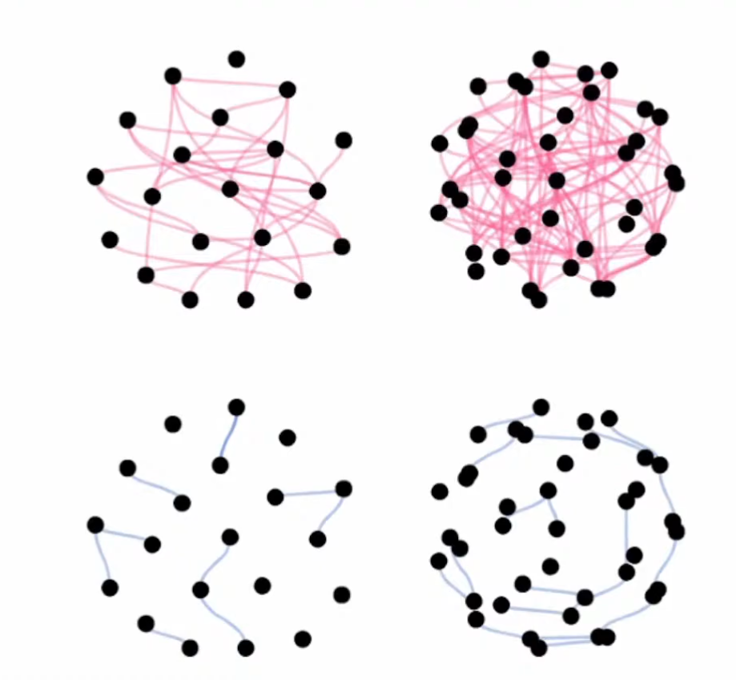

In **frequency-dependent (FD) transmission**, the per capita contact rate between susceptible (S) and infected (I) individuals **does not depend** on the population density. So transmission rates do not change with density. i.e., the number of transmissions per person in a crowded area vs. a sparsely populated area will be roughly the same.

**Population density** is measured as the total number of individuals per unit area.

Notice that in the two network figures above, the area is constant – i.e., the size of the circles are the same, it is only the number of individuals that increases. For the purposes of this lesson, we will assume that the area (A) of disease spread remains constant, and only the total population size (N) is changing. Therefor the population density (N/A) is equal to N.

**Contact rate** is probability of contact of an appropriate type for transmission to be possible if one of the hosts is infectious.

The meaning of “contact” can change depending on the disease. For an airborne pathogen, an eligible contact between individuals mean that they breathe the same air. For a blood-borne pathogen, a contact may require sharing needles or other injection equipment.

## 1.1 Examples

Density dependence may be seen in airborne pathogens in a closed space like an airplane cabin. If you have twice as many people in the same area, it’s likely that you will get twice as many “exposure events” or contacts because all of these people are breathing the same air.

But there are some types of contacts that don’t become increasingly more likely as population density increases. For example, a disease transmitted by bodily fluids or touch (such as via PDA) may exhibit frequency-dependence. Adding more individuals to the same room does not necessarily mean that those individuals are more likely to be making out.

**Practice Question**

In the image below, as the same number of people are pushed into a smaller area, the number of contacts increases.

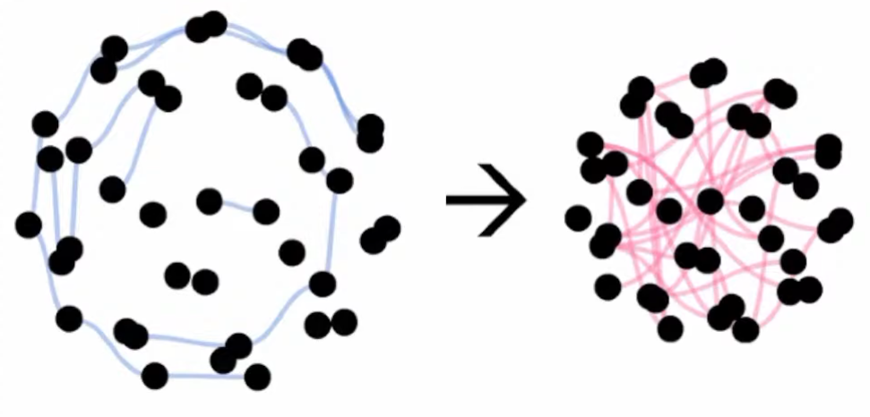

This is an example of:

1. Density-dependence
2. Frequency-dependence

## 1.2 The contact rate function

The first, and most frequently assumed possibility is that the rate of contact increases directly with the density of the population.

A commonly assumed alternative possibility is that the rate of contact is constant irrespective of the density of the population.

We can visualize this with a simple graph.

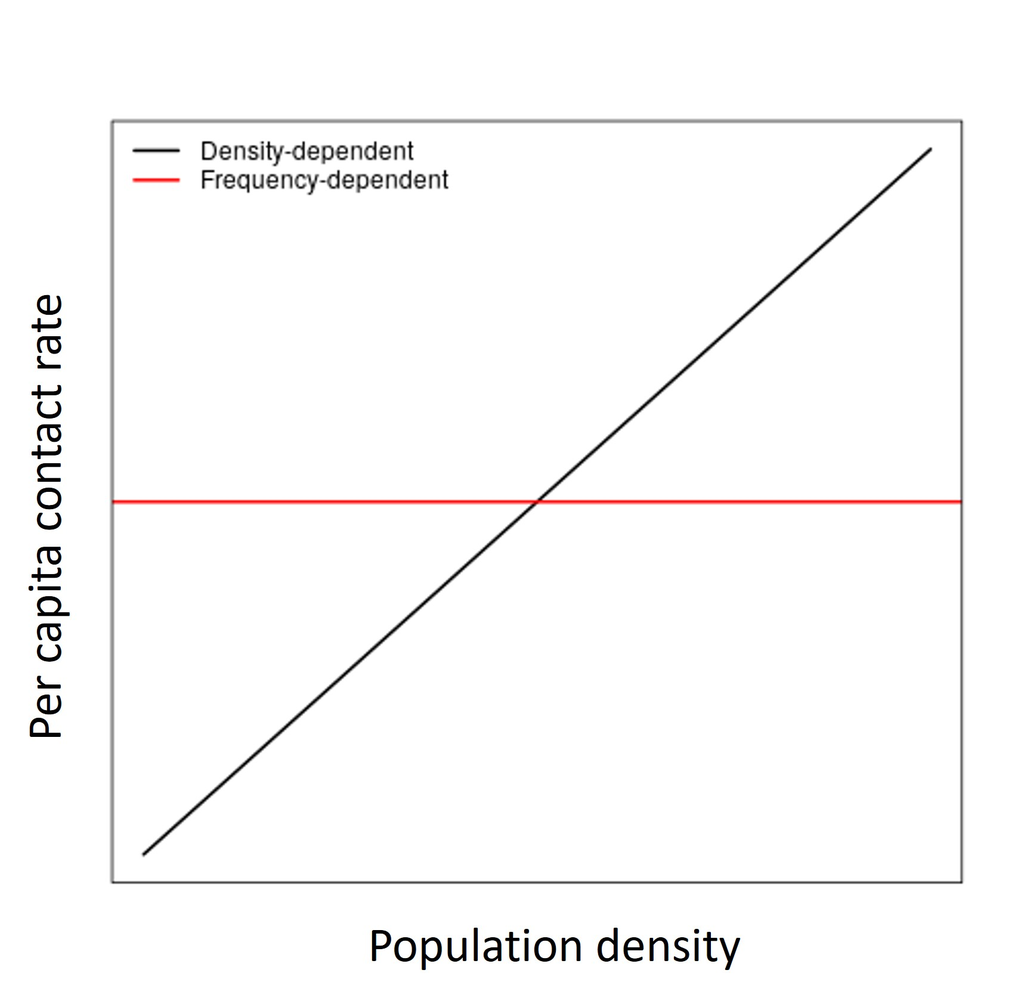

**The difference between density-dependent (DD) and frequency-dependent (FD) transmission**

To recap, the difference is all about the shape of the contact rate function with regards to host density:

- In FD transmission, contact rate is assumed to be independent of host density.
- In DD transmission, contact rate is assumed to linearly increase with host density.

# 2 Decomposing Transmission: The $\beta$ parameter of the SIR model

## 2.1 Recap of the SIR Model Framework

The SIR model divides the population into three compartments:

- **Susceptible (S)**: Individuals who can contract the disease-causing pathogen.
- **Infectious (I)**: Individuals who have contracted the pathogen and can transmit it to others.
- **Recovered (R)**: Individuals who have recovered from the disease and have immunity against it.

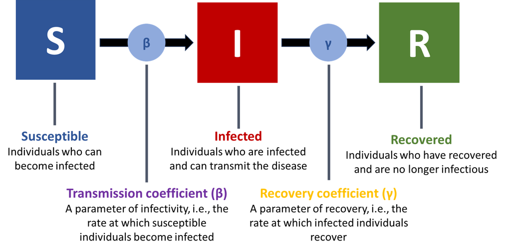

### 2.1.1 DD ODEs

The transitions between these in states in a DD model are governed by the following differential equations:

$$\frac{dS}{dt} = - \beta SI$$

$$\frac{dI}{dt} = \beta SI - \gamma I$$

$$\frac{dR}{dt} = \gamma I$$

The transmission rate of the model described above is $\beta SI$.

### 2.1.2 FD ODEs

$$\frac{dS}{dt} = - \frac{\beta SI}{N}$$

$$\frac{dI}{dt} = \frac{\beta SI}{N} -
\gamma I$$

$$\frac{dR}{dt} = \gamma I$$

The transmission rate of the model described above is $\frac{\beta SI}{N}$.

# 3 Calculating beta for different types of transmission

Transmission can be broken down into three separate processes:

$$\text{Transmission rate} \propto
\text{Contacts} \times P(Infectious) \times P(Transmission)$$

The transmission rate can be thought of as a “conglomerate” rate because it is a combination of other rates. It can be expressed as:

$$\text{Transmission rate} = S \times
c(N) \times \frac{I}{N} \times \nu$$

## 3.1 The DD and FD Contact Rates are Different

In DD transmission, the contact rate (c) depends on the population density. In FD transmission, the contact rate (c’) does not depend on the population density. This is the main difference between density-dependent and frequency-dependent transmission.

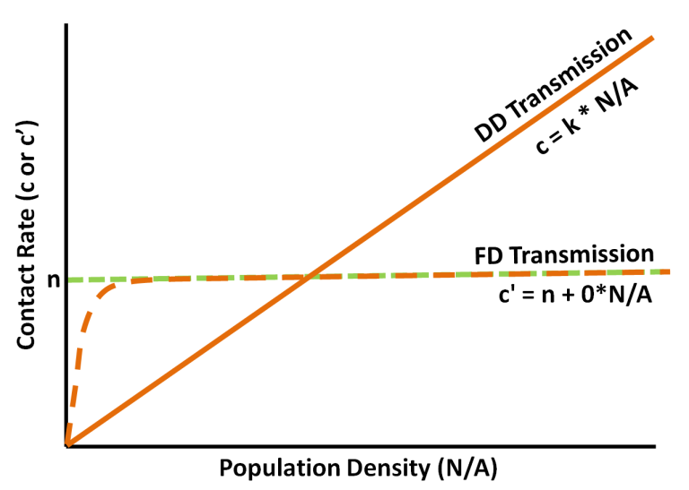

- *In DD transmission*, the contact rate (c) increases with the population density, where density is just the total number of individuals in the population (N) divided by the area (A). We usually assume that the relationship between c and N/A is linear, with a slope of k. However, we don’t need to assume a linear relationship if a different shape makes more sense.
- *In FD transmission*, the contact rate (c’) is usually not affected by the population density (N/A) – see the green dashed line. That is, the line for c’ has an intercept of n and a slope of 0. The caveat being that at in some cases, c’ does increase with density at very low densities – see the orange dashed line.

**Equation of a Straight Line**

y = mx + c

where m is slope of the line (in this case, kappa for DD), and c is the intercept (in this case, n for FD)

## 3.2 Dr. Blue

Sometimes it is easier to say those two sentences than to truly understand what they mean, so let’s do a little thought experiment:

Dr. Blue is going clubbing. Dr. Blue can either go to Club 1 or Club 2. It is flu season, and while deciding which club to frequent, Dr. Blue wonders whether Club 1 or Club 2 is better for avoiding disease transmission. The two clubs are exactly the same size (A<sub>1</sub> = A<sub>2</sub> = 1), but Club 2 always has more people than Club 1 (N<sub>1</sub> < N<sub>2</sub>; i.e., Club 2 has a higher density). Dr. Blue realizes that the contact rate with other people will be higher in Club 2 because the density is greater. That is, the contact rate (c) is density-dependent. The more people in the club, the more likely Dr. Blue is to get close enough to one of them to acquire some of their germs.

[figure not shown]

In the previous scenario, we were talking about the types of contacts that lead to transmission of the flu, rhinovirus, etc. What if we were talking about STDs instead? Does the probability of contact leading to an STD infection (i.e., the probability of having sex with one of the club-goers) increase with the density of people in the club? No (for the most part). If Dr. Blue is going to have sex with one of the club-goers, it is unlikely to depend on whether there are 50 or 100 club-goers. **The contact rate (c’) is not density-dependent.** The caveat is that contact rate might be density-dependent at very low densities. Like, if Dr. Blue walks into the club and there are only two club-goers, both of whom have not bathed in a year, the probability of sexual contact will likely be much lower than if Dr. Blue walks into a club with 50 club-goers. (But hey, whatever floats your boat, Dr. Blue.)

We can summarize what we’ve learned about contact rates in DD and FD transmission in a graph.

[figure not shown]

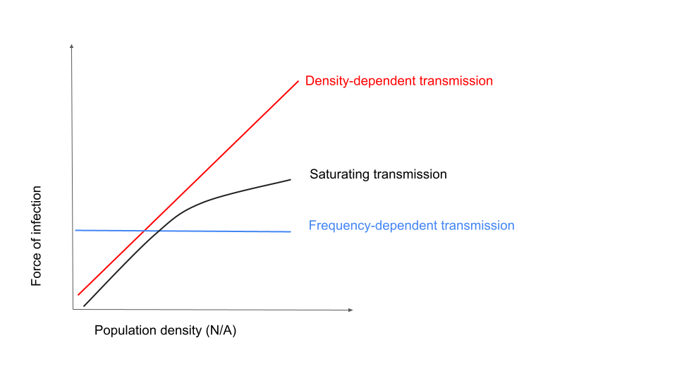

## 3.3 Density Dependent Transmission (DD)

In density-dependent transmission, the contact rate ($c(N)$) scales with population density. Here, transmission rates increase with density:

$$\text{Transmission rate} = S \times
\kappa N \times \frac{I}{N} \times \nu = SI\kappa \nu = \beta SI$$

$$\beta = \kappa \nu$$

## 3.4 Frequency Dependent Transmission (FD)

In frequency-dependent transmission, the contact rate ($c$) is constant regardless of population density. Thus, transmission rates do not change with density:

$$\text{Transmission rate} = S \times
\kappa \times \frac{I}{N} \times \nu = \frac{SI\kappa \nu}{N} =
\frac{\beta SI}{N}$$

# 4 When to model DD or FD

- Frequency-dependent transmission is typically more appropriate for large populations with heterogeneous mixing, sexually transmitted diseases, and vector-borne pathogens.
- Density-dependent transmission is usually used to represent diseases in wildlife and livestock, especially in smaller population sizes.
- Empirical evidence suggests that many disease systems are intermediate, necessitating a flexible approach to modeling transmission dynamics.

# 5 Disease Transmission Routes

## 5.1 Directly transmitted diseases

Close contact between susceptible and infectious individuals in close proximity.

- **Person-to-person contact** - transmitted via touch or through the skin or mucus membranes (e.g., Ebola, hookworm, scabies).
- **Respiratory droplet transmission** (e.g., COVID-19, pandemic influenza, tuberculosis)
- **Sexually transmitted infections (STIs)** and intravenous infections (e.g., HIV, syphilis, Hepatitis B)

## 5.2 Indirect contact transmission

- **Airborne transmission** – caused by pathogens that spread through the air when an infected person coughs, sneezes, talks, or even breathes (e.g., measles, chicken pox, influenza)
- **Food-and-drink borne diseases**: pathogens are transmitted by ingesting food or drink.
  - E.g., Cholera (water), brucellosis (milk), *E.coli* (meat or produce)
- **Insect vector-borne**: Involving intermediaries such as:
  - Mosquitoes (e.g., malaria, dengue, Zika)
  - Fleas (e.g., typhus, plague)
  - Ticks (e.g., Lyme disease, Rocky Mountain spotted fever)
- **Environmental**: Involving contamination of surroundings. Soil, water, and vegetation containing infectious organisms.
  - Tetanus
  - Botulism
  - Cholera
- **Zoonotic** - Animal-to-human transmission, such as:
  - Nipah Virus
  - Hendra Virus

# 6 Conclusion

# Contributors

The following team members contributed to this lesson:

- [JOY VAZ](https://thegraphcourses.org/members/joy)  
  R Developer and Instructor, the GRAPH Network

  Loves doing science and teaching science
- [SABINA RODRIGUEZ VELÁSQUEZ](https://thegraphcourses.org/members/sabina0104/)  
  Project Manager and Scientific Collaborator, The GRAPH Network

  Infectiously enthusiastic about microbes and Global Health

# 7 References

- https://www.healthline.com/health/disease-transmission
- https://www.gresham.ac.uk/watch-now/series/infections
- https://parasiteecology.wordpress.com/2014/02/26/parasite-transmission-density-dependent-frequency-dependent-or-neither/
- https://parasiteecology.wordpress.com/2013/10/17/density-dependent-vs-frequency-dependent-disease-transmission/
- http://dimacs.rutgers.edu/archive/Workshops/AIMS/slides/JLS_ASI_3.pdf
- https://pmc.ncbi.nlm.nih.gov/articles/PMC2869860/pdf/12211582.pdf
- https://andreashandel.github.io/IDEMAbook/modes-of-direct-transmission.html#ways-in-which-direct-transmission-scales
- https://www.youtube.com/watch?v=V0TBsGckUYM&ab_channel=GlobalHealthwithGregMartin

This work is licensed under the [Creative Commons Attribution Share Alike](https://creativecommons.org/licenses/by-sa/4.0/) license.